# Google Capstone Project - Cyclist

Kevin Narvaes

3/9/2022

For our analysis, we will be looking at the Cyclistic bike-share company, a fictional company which will requiere to apply put analytic knowledge in order to get useful insights.

# Ask

We are going to determine how annual members and casual riders differ from each other, in order to take future decisions like determining what are the best occasions for special offers, and knowing the habits of our members to know how to accommodate to their demands.

We will be using R for our analysis to get a variety of insights.

# Prepare

## Importing Our Main Libraries

```r
#Imported libraries
library(tidyverse)    #for data cleaning
```

```r
library(ggplot2)      #plotting
library(skimr)        #analysis from attributes
library(lubridate)    #Working with dates
library(RColorBrewer) #Setting color to plots
library(formattable)  #Formatting numbers
library(ggthemes)     #predetermined themes for plots
library(extrafont)    #Additional fonts
```

## Our Data Source

Our data is hosted in this [link](https://divvy-tripdata.s3.amazonaws.com/index.html)

Note: The datasets have a different name because Cyclistic is a fictional company. For the purposes of this case study, the datasets are appropriate and will enable you to answer the business questions. The data has been made available Motivate International Inc.) This is public data that you can use to explore how different customer types are using Cyclistic bikes. But note that data-privacy issues prohibit you from using riders’ personally identifiable information.

We download the files on the main directory, on a Data folder.

We proceed to use the list.files function to get the list of all our csv files in our folder, then we apply the map_df in order to read each of them and append them together.

```r
cyclist_data <- list.files(path = "./Data", full.names = TRUE) %>%
  map_df(~read_csv(.))
```

## Exploring our data

We proceed to check our column names

```r
colnames(cyclist_data)
```

```
##  [1] "ride_id"            "rideable_type"      "started_at"
##  [4] "ended_at"           "start_station_name" "start_station_id"
##  [7] "end_station_name"   "end_station_id"     "start_lat"
## [10] "start_lng"          "end_lat"            "end_lng"
## [13] "member_casual"
```

We proceed to rename our columns to a more understandable name

```r
cyclist_data_names_fixed <- cyclist_data %>%
  rename(started_datetime = started_at,
         ended_datetime = ended_at)
colnames(cyclist_data_names_fixed)
```

```
##  [1] "ride_id"            "rideable_type"      "started_datetime"
##  [4] "ended_datetime"     "start_station_name" "start_station_id"
##  [7] "end_station_name"   "end_station_id"     "start_lat"
## [10] "start_lng"          "end_lat"            "end_lng"
## [13] "member_casual"
```

We will use out skimr function to check our column stats.

```r
skim_without_charts(cyclist_data_names_fixed)
```

Data summary

| Name | cyclist_data_names_fixed |
| --- | --- |
| Number of rows | 5595063 |
| Number of columns | 13 |
| _______________________ |  |
| Column type frequency: |  |
| character | 7 |
| numeric | 4 |
| POSIXct | 2 |
| ________________________ |  |
| Group variables | None |

**Variable type: character**

| skim_variable | n_missing | complete_rate | min | max | empty | n_unique | whitespace |
| --- | --- | --- | --- | --- | --- | --- | --- |
| ride_id | 0 | 1.00 | 16 | 16 | 0 | 5595063 | 0 |
| rideable_type | 0 | 1.00 | 11 | 13 | 0 | 3 | 0 |
| start_station_name | 690809 | 0.88 | 3 | 53 | 0 | 847 | 0 |
| start_station_id | 690806 | 0.88 | 3 | 36 | 0 | 834 | 0 |
| end_station_name | 739170 | 0.87 | 10 | 53 | 0 | 844 | 0 |
| end_station_id | 739170 | 0.87 | 3 | 36 | 0 | 832 | 0 |
| member_casual | 0 | 1.00 | 6 | 6 | 0 | 2 | 0 |

**Variable type: numeric**

| skim_variable | n_missing | complete_rate | mean | sd | p0 | p25 | p50 | p75 | p100 |
| --- | --- | --- | --- | --- | --- | --- | --- | --- | --- |
| start_lat | 0 | 1 | 41.90 | 0.05 | 41.64 | 41.88 | 41.90 | 41.93 | 42.07 |
| start_lng | 0 | 1 | -87.65 | 0.03 | -87.84 | -87.66 | -87.64 | -87.63 | -87.52 |
| end_lat | 4771 | 1 | 41.90 | 0.05 | 41.39 | 41.88 | 41.90 | 41.93 | 42.17 |
| end_lng | 4771 | 1 | -87.65 | 0.03 | -88.97 | -87.66 | -87.64 | -87.63 | -87.49 |

**Variable type: POSIXct**

| skim_variable | n_missing | complete_rate | min | max | median | n_unique |
| --- | --- | --- | --- | --- | --- | --- |
| started_datetime | 0 | 1 | 2021-01-01 00:02:05 | 2021-12-31 23:59:48 | 2021-08-01 01:52:11 | 4677998 |
| ended_datetime | 0 | 1 | 2021-01-01 00:08:39 | 2022-01-03 17:32:18 | 2021-08-01 02:21:55 | 4671372 |

# Process

## Dealing with empty values

First we check how many empty values we have per attribute.

```r
cyclist_data_names_fixed %>%
  summarize(empty_rideable_type = sum(is.na(rideable_type)),
            empty_start_station_name = sum(is.na(start_station_name)),
            empty_end_station_name = sum(is.na(end_station_name)),
            empty_started_datetime = sum(is.na(started_datetime)),
            empty_ended_datetime = sum(is.na(ended_datetime))
            ) %>%
  t(.)
```

```
##                            [,1]
## empty_rideable_type           0
## empty_start_station_name 690809
## empty_end_station_name   739170
## empty_started_datetime        0
## empty_ended_datetime          0
```

Then we proceed to replace any empty values using mutate on the columns that we are intesrested in.

```r
cyclist_data_no_empty <-cyclist_data_names_fixed %>%
  mutate(start_station_name = coalesce(start_station_name, 'Unknown'),
         start_station_id = coalesce(start_station_id, '0'),
         end_station_name = coalesce(end_station_name, 'Unknown'),
         end_station_id = coalesce(end_station_id, '0'),
         )
```

We’ll now do the proper calculations. We are interested on how much time each ride takes, and make time analysis based on month and day of the week. We’ll use the mutate function for that.

```r
cyclist_data_time <- cyclist_data_no_empty %>%
  mutate(traveled_time_mins = difftime(ended_datetime, started_datetime, units = "mins"),
         traveled_time_hours = difftime(ended_datetime, started_datetime, units = "hours"),
         month = month(started_datetime, label = TRUE),
         day_of_week_started = wday(started_datetime, label = TRUE)
         )
```

Since we will be analyzing how Cyclistic Member Types differ, we’ll be using color coding for each member type. We’ll set the color hex codes on a vector so we can distinguish them on visuals

```r
plot_colors <-  c("#5BE0FF", "#6D5BFF")
```

We are now ready to proceed with our analysis process

# Analyze

We want to know how annual members and casual riders differ based on the total rides of each group per month, to check if there’s a trend among each other. We’ll use a line chart for comparing trends.

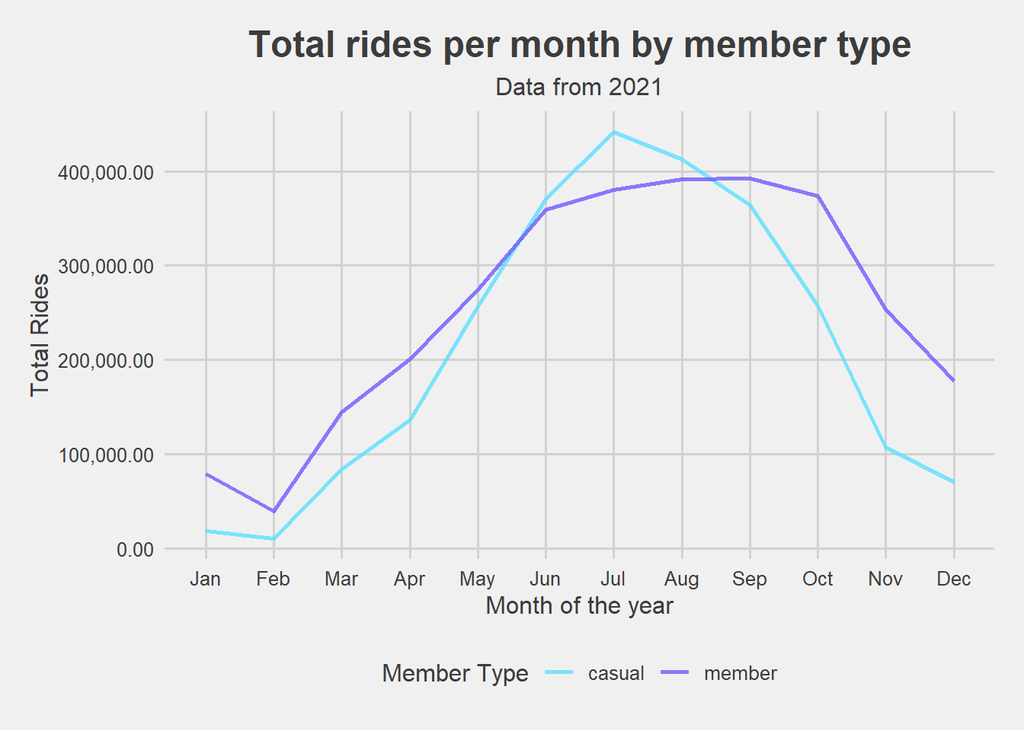

```r
cyclist_data_time %>%
  group_by(month = month(started_datetime, label = TRUE), member_casual) %>%
  summarize(total_rides = n()) %>%
  ggplot() +
  geom_line(mapping = aes(x = month, y = total_rides, group = member_casual, color = member_casual),
            linetype = "solid", size = 1, alpha = 0.8) +
  theme_fivethirtyeight() +
  scale_color_manual(values = plot_colors) +
  scale_y_continuous(labels = comma) +
  labs(title = 'Total rides per month by member type',
       subtitle = "Data from 2021",
       x = "Month of the year",
       y = "Total Rides",
       color = "Member Type") +
  theme(plot.title = element_text(hjust = 0.5),
        plot.subtitle = element_text(hjust = 0.5),
        axis.title = element_text())
```

Then, we will check how they differ based on their rideable type of preference.

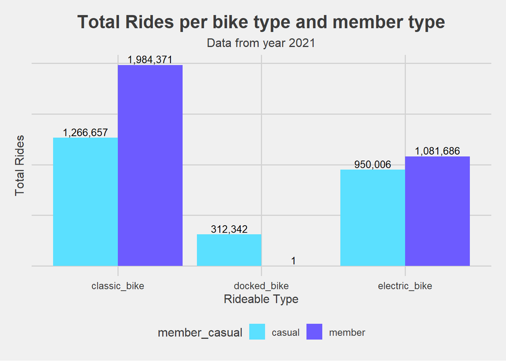

```r
ggplot(data = cyclist_data_time) +
  geom_bar(mapping = aes(x = rideable_type, group = member_casual, fill = member_casual),
           stat="count",
           position = "dodge") +
  theme_fivethirtyeight() +
  stat_count(aes(x = rideable_type,group =member_casual, label = comma(..count.., digits = 0)),
             geom = "text", color = "black", size = 3.5,
             position = position_dodge(width = 0.9),vjust =  -0.25) +
  scale_fill_manual(values = plot_colors)+
  labs(title = "Total Rides per bike type and member type",
       subtitle = "Data from year 2021",
       y ="Total Rides",
       x = "Rideable Type",
       color = "Member Type") +
  theme(plot.title = element_text(hjust = 0.5),
        plot.subtitle = element_text(hjust = 0.5),
        axis.text.y = element_blank(),
        axis.title.y = element_text(),
        axis.title.x = element_text())
```

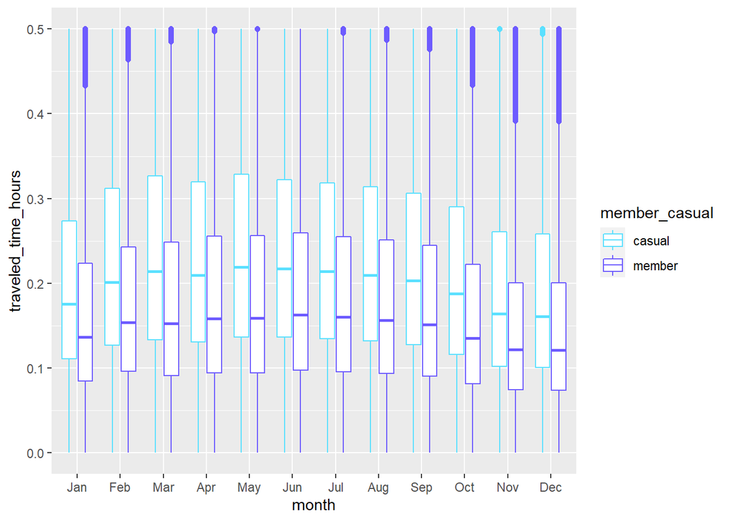

```r
cyclist_data_time %>%
  filter(cyclist_data_time$traveled_time_hours <= 0.5 & cyclist_data_time$traveled_time_hours >= 0) %>%
  mutate(month = month(started_datetime, label = TRUE)) %>%
  ggplot() +
  geom_boxplot(mapping = aes(x = month, y = traveled_time_hours,color = member_casual))+
  scale_color_manual(values = plot_colors)
```